# Risk Factor Analysis

## Outcome Variable

**Outcome Variable:** y_rate_len

## Predictor Variables

**Intervention Variable:** nhh

**Adjustment Set:**

unadjusted

## Stratifying Variables

The analysis was stratified on these variable(s):

- agecat
- studyid
- country

## Data Summary

| agecat | studyid | country | nhh | n_cell | n |
| --- | --- | --- | --- | --- | --- |
| 0-3 months | ki1000108-IRC | INDIA | 3 or less | 53 | 377 |
| 0-3 months | ki1000108-IRC | INDIA | 4-5 | 146 | 377 |
| 0-3 months | ki1000108-IRC | INDIA | 6-7 | 99 | 377 |
| 0-3 months | ki1000108-IRC | INDIA | 8+ | 79 | 377 |
| 0-3 months | ki1017093-NIH-Birth | BANGLADESH | 3 or less | 101 | 566 |
| 0-3 months | ki1017093-NIH-Birth | BANGLADESH | 4-5 | 239 | 566 |
| 0-3 months | ki1017093-NIH-Birth | BANGLADESH | 6-7 | 132 | 566 |
| 0-3 months | ki1017093-NIH-Birth | BANGLADESH | 8+ | 94 | 566 |
| 0-3 months | ki1017093b-PROVIDE | BANGLADESH | 3 or less | 123 | 634 |
| 0-3 months | ki1017093b-PROVIDE | BANGLADESH | 4-5 | 291 | 634 |
| 0-3 months | ki1017093b-PROVIDE | BANGLADESH | 6-7 | 135 | 634 |
| 0-3 months | ki1017093b-PROVIDE | BANGLADESH | 8+ | 85 | 634 |
| 0-3 months | ki1017093c-NIH-Crypto | BANGLADESH | 3 or less | 107 | 720 |
| 0-3 months | ki1017093c-NIH-Crypto | BANGLADESH | 4-5 | 324 | 720 |
| 0-3 months | ki1017093c-NIH-Crypto | BANGLADESH | 6-7 | 169 | 720 |
| 0-3 months | ki1017093c-NIH-Crypto | BANGLADESH | 8+ | 120 | 720 |
| 3-6 months | ki1000108-IRC | INDIA | 3 or less | 57 | 397 |
| 3-6 months | ki1000108-IRC | INDIA | 4-5 | 154 | 397 |
| 3-6 months | ki1000108-IRC | INDIA | 6-7 | 103 | 397 |
| 3-6 months | ki1000108-IRC | INDIA | 8+ | 83 | 397 |
| 3-6 months | ki1017093-NIH-Birth | BANGLADESH | 3 or less | 89 | 523 |
| 3-6 months | ki1017093-NIH-Birth | BANGLADESH | 4-5 | 223 | 523 |
| 3-6 months | ki1017093-NIH-Birth | BANGLADESH | 6-7 | 126 | 523 |
| 3-6 months | ki1017093-NIH-Birth | BANGLADESH | 8+ | 85 | 523 |
| 3-6 months | ki1017093b-PROVIDE | BANGLADESH | 3 or less | 102 | 574 |
| 3-6 months | ki1017093b-PROVIDE | BANGLADESH | 4-5 | 270 | 574 |
| 3-6 months | ki1017093b-PROVIDE | BANGLADESH | 6-7 | 124 | 574 |
| 3-6 months | ki1017093b-PROVIDE | BANGLADESH | 8+ | 78 | 574 |
| 3-6 months | ki1017093c-NIH-Crypto | BANGLADESH | 3 or less | 101 | 695 |
| 3-6 months | ki1017093c-NIH-Crypto | BANGLADESH | 4-5 | 316 | 695 |
| 3-6 months | ki1017093c-NIH-Crypto | BANGLADESH | 6-7 | 163 | 695 |
| 3-6 months | ki1017093c-NIH-Crypto | BANGLADESH | 8+ | 115 | 695 |
| 6-12 months | ki1000108-IRC | INDIA | 3 or less | 57 | 400 |
| 6-12 months | ki1000108-IRC | INDIA | 4-5 | 154 | 400 |
| 6-12 months | ki1000108-IRC | INDIA | 6-7 | 104 | 400 |
| 6-12 months | ki1000108-IRC | INDIA | 8+ | 85 | 400 |
| 6-12 months | ki1000304b-SAS-FoodSuppl | INDIA | 3 or less | 26 | 332 |
| 6-12 months | ki1000304b-SAS-FoodSuppl | INDIA | 4-5 | 146 | 332 |
| 6-12 months | ki1000304b-SAS-FoodSuppl | INDIA | 6-7 | 106 | 332 |
| 6-12 months | ki1000304b-SAS-FoodSuppl | INDIA | 8+ | 54 | 332 |
| 6-12 months | ki1017093-NIH-Birth | BANGLADESH | 3 or less | 87 | 482 |
| 6-12 months | ki1017093-NIH-Birth | BANGLADESH | 4-5 | 202 | 482 |
| 6-12 months | ki1017093-NIH-Birth | BANGLADESH | 6-7 | 112 | 482 |
| 6-12 months | ki1017093-NIH-Birth | BANGLADESH | 8+ | 81 | 482 |
| 6-12 months | ki1017093b-PROVIDE | BANGLADESH | 3 or less | 97 | 545 |
| 6-12 months | ki1017093b-PROVIDE | BANGLADESH | 4-5 | 258 | 545 |
| 6-12 months | ki1017093b-PROVIDE | BANGLADESH | 6-7 | 114 | 545 |
| 6-12 months | ki1017093b-PROVIDE | BANGLADESH | 8+ | 76 | 545 |
| 6-12 months | ki1017093c-NIH-Crypto | BANGLADESH | 3 or less | 95 | 676 |
| 6-12 months | ki1017093c-NIH-Crypto | BANGLADESH | 4-5 | 307 | 676 |
| 6-12 months | ki1017093c-NIH-Crypto | BANGLADESH | 6-7 | 164 | 676 |
| 6-12 months | ki1017093c-NIH-Crypto | BANGLADESH | 8+ | 110 | 676 |
| 6-12 months | ki1148112-LCNI-5 | MALAWI | 3 or less | 119 | 430 |
| 6-12 months | ki1148112-LCNI-5 | MALAWI | 4-5 | 183 | 430 |
| 6-12 months | ki1148112-LCNI-5 | MALAWI | 6-7 | 95 | 430 |
| 6-12 months | ki1148112-LCNI-5 | MALAWI | 8+ | 33 | 430 |
| 12-24 months | ki1000108-IRC | INDIA | 3 or less | 57 | 396 |
| 12-24 months | ki1000108-IRC | INDIA | 4-5 | 151 | 396 |
| 12-24 months | ki1000108-IRC | INDIA | 6-7 | 103 | 396 |
| 12-24 months | ki1000108-IRC | INDIA | 8+ | 85 | 396 |
| 12-24 months | ki1017093-NIH-Birth | BANGLADESH | 3 or less | 74 | 421 |
| 12-24 months | ki1017093-NIH-Birth | BANGLADESH | 4-5 | 181 | 421 |
| 12-24 months | ki1017093-NIH-Birth | BANGLADESH | 6-7 | 97 | 421 |
| 12-24 months | ki1017093-NIH-Birth | BANGLADESH | 8+ | 69 | 421 |
| 12-24 months | ki1017093b-PROVIDE | BANGLADESH | 3 or less | 86 | 458 |
| 12-24 months | ki1017093b-PROVIDE | BANGLADESH | 4-5 | 213 | 458 |
| 12-24 months | ki1017093b-PROVIDE | BANGLADESH | 6-7 | 96 | 458 |
| 12-24 months | ki1017093b-PROVIDE | BANGLADESH | 8+ | 63 | 458 |
| 12-24 months | ki1017093c-NIH-Crypto | BANGLADESH | 3 or less | 68 | 495 |
| 12-24 months | ki1017093c-NIH-Crypto | BANGLADESH | 4-5 | 224 | 495 |
| 12-24 months | ki1017093c-NIH-Crypto | BANGLADESH | 6-7 | 125 | 495 |
| 12-24 months | ki1017093c-NIH-Crypto | BANGLADESH | 8+ | 78 | 495 |
| 12-24 months | ki1148112-LCNI-5 | MALAWI | 3 or less | 89 | 307 |
| 12-24 months | ki1148112-LCNI-5 | MALAWI | 4-5 | 130 | 307 |
| 12-24 months | ki1148112-LCNI-5 | MALAWI | 6-7 | 64 | 307 |
| 12-24 months | ki1148112-LCNI-5 | MALAWI | 8+ | 24 | 307 |

The following strata were considered:

- agecat: 0-3 months, studyid: ki1000108-IRC, country: INDIA
- agecat: 0-3 months, studyid: ki1017093-NIH-Birth, country: BANGLADESH
- agecat: 0-3 months, studyid: ki1017093b-PROVIDE, country: BANGLADESH
- agecat: 0-3 months, studyid: ki1017093c-NIH-Crypto, country: BANGLADESH
- agecat: 12-24 months, studyid: ki1000108-IRC, country: INDIA
- agecat: 12-24 months, studyid: ki1017093-NIH-Birth, country: BANGLADESH
- agecat: 12-24 months, studyid: ki1017093b-PROVIDE, country: BANGLADESH
- agecat: 12-24 months, studyid: ki1017093c-NIH-Crypto, country: BANGLADESH
- agecat: 12-24 months, studyid: ki1148112-LCNI-5, country: MALAWI
- agecat: 3-6 months, studyid: ki1000108-IRC, country: INDIA
- agecat: 3-6 months, studyid: ki1017093-NIH-Birth, country: BANGLADESH
- agecat: 3-6 months, studyid: ki1017093b-PROVIDE, country: BANGLADESH
- agecat: 3-6 months, studyid: ki1017093c-NIH-Crypto, country: BANGLADESH
- agecat: 6-12 months, studyid: ki1000108-IRC, country: INDIA
- agecat: 6-12 months, studyid: ki1000304b-SAS-FoodSuppl, country: INDIA
- agecat: 6-12 months, studyid: ki1017093-NIH-Birth, country: BANGLADESH
- agecat: 6-12 months, studyid: ki1017093b-PROVIDE, country: BANGLADESH
- agecat: 6-12 months, studyid: ki1017093c-NIH-Crypto, country: BANGLADESH
- agecat: 6-12 months, studyid: ki1148112-LCNI-5, country: MALAWI

## Methods Detail

We’re interested in the causal parameters $E[Y_a]$ for all values of $a \in \mathcal{A}$. These parameters represent the mean outcome if, possibly contrary to fact, we intervened to set all units to have $A=a$. Under the randomization and positivity assumptions, these are identified by the statistical parameters $\psi_a=E_W[E_{Y|A,W}(Y|A=a,W)]$. In addition, we’re interested in the mean of $Y$, $E[Y]$ under no intervention (the observed mean). We will estimate these parameters by using SuperLearner to fit the relevant likelihood factors – $E_{Y|A,W}(Y|A=a,W)$ and $p(A=a|W)$, and then updating our likelihood fit using a joint TMLE.

For unadjusted analyses ($W=\{\}$), initial likelihoods were estimated using Lrnr_glm to estimate the simple $E(Y|A)$ and Lrnr_mean to estimate $p(A)$. For adjusted analyses, a small library containing Lrnr_glmnet, Lrnr_xgboost, and Lrnr_mean was used.

Having estimated these parameters, we will then use the delta method to estimate relative risks and attributable risks relative to a prespecified baseline level of $A$.

# Results Detail

## Results Plots

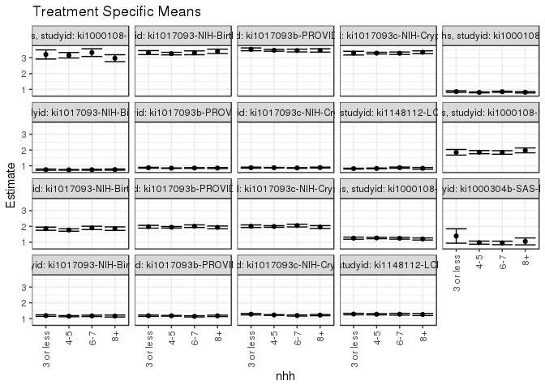

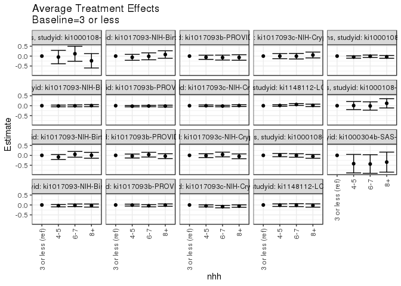

## Results Table

### Parameter: TSM

| agecat | studyid | country | intervention_level | baseline_level | estimate | ci_lower | ci_upper |
| --- | --- | --- | --- | --- | --- | --- | --- |
| 0-3 months | ki1000108-IRC | INDIA | 3 or less | NA | 3.2102578 | 2.9204285 | 3.5000872 |
| 0-3 months | ki1000108-IRC | INDIA | 4-5 | NA | 3.1617845 | 2.9879202 | 3.3356487 |
| 0-3 months | ki1000108-IRC | INDIA | 6-7 | NA | 3.3280043 | 3.0853992 | 3.5706094 |
| 0-3 months | ki1000108-IRC | INDIA | 8+ | NA | 2.9741059 | 2.7537214 | 3.1944903 |
| 0-3 months | ki1017093-NIH-Birth | BANGLADESH | 3 or less | NA | 3.3286040 | 3.2030448 | 3.4541633 |
| 0-3 months | ki1017093-NIH-Birth | BANGLADESH | 4-5 | NA | 3.2663625 | 3.1864322 | 3.3462928 |
| 0-3 months | ki1017093-NIH-Birth | BANGLADESH | 6-7 | NA | 3.3168469 | 3.1946488 | 3.4390450 |
| 0-3 months | ki1017093-NIH-Birth | BANGLADESH | 8+ | NA | 3.4089613 | 3.2700546 | 3.5478681 |
| 0-3 months | ki1017093b-PROVIDE | BANGLADESH | 3 or less | NA | 3.5351810 | 3.4449892 | 3.6253727 |
| 0-3 months | ki1017093b-PROVIDE | BANGLADESH | 4-5 | NA | 3.4759663 | 3.4188332 | 3.5330993 |
| 0-3 months | ki1017093b-PROVIDE | BANGLADESH | 6-7 | NA | 3.4601248 | 3.3738610 | 3.5463887 |
| 0-3 months | ki1017093b-PROVIDE | BANGLADESH | 8+ | NA | 3.4654455 | 3.3600111 | 3.5708798 |
| 0-3 months | ki1017093c-NIH-Crypto | BANGLADESH | 3 or less | NA | 3.2957774 | 3.1781573 | 3.4133976 |
| 0-3 months | ki1017093c-NIH-Crypto | BANGLADESH | 4-5 | NA | 3.2947828 | 3.2401833 | 3.3493823 |
| 0-3 months | ki1017093c-NIH-Crypto | BANGLADESH | 6-7 | NA | 3.2896118 | 3.2131459 | 3.3660778 |
| 0-3 months | ki1017093c-NIH-Crypto | BANGLADESH | 8+ | NA | 3.3496751 | 3.2596599 | 3.4396904 |
| 3-6 months | ki1000108-IRC | INDIA | 3 or less | NA | 1.8557049 | 1.6789502 | 2.0324597 |
| 3-6 months | ki1000108-IRC | INDIA | 4-5 | NA | 1.8635369 | 1.7631241 | 1.9639496 |
| 3-6 months | ki1000108-IRC | INDIA | 6-7 | NA | 1.8428990 | 1.7307262 | 1.9550718 |
| 3-6 months | ki1000108-IRC | INDIA | 8+ | NA | 1.9764948 | 1.8224050 | 2.1305845 |
| 3-6 months | ki1017093-NIH-Birth | BANGLADESH | 3 or less | NA | 1.8554196 | 1.7566027 | 1.9542365 |
| 3-6 months | ki1017093-NIH-Birth | BANGLADESH | 4-5 | NA | 1.7716974 | 1.6957499 | 1.8476449 |
| 3-6 months | ki1017093-NIH-Birth | BANGLADESH | 6-7 | NA | 1.9068145 | 1.8026687 | 2.0109602 |
| 3-6 months | ki1017093-NIH-Birth | BANGLADESH | 8+ | NA | 1.8590372 | 1.7486418 | 1.9694326 |
| 3-6 months | ki1017093b-PROVIDE | BANGLADESH | 3 or less | NA | 1.9798651 | 1.8923861 | 2.0673442 |
| 3-6 months | ki1017093b-PROVIDE | BANGLADESH | 4-5 | NA | 1.9451542 | 1.8961634 | 1.9941450 |
| 3-6 months | ki1017093b-PROVIDE | BANGLADESH | 6-7 | NA | 2.0149879 | 1.9333410 | 2.0966349 |
| 3-6 months | ki1017093b-PROVIDE | BANGLADESH | 8+ | NA | 1.9380676 | 1.8509907 | 2.0251445 |
| 3-6 months | ki1017093c-NIH-Crypto | BANGLADESH | 3 or less | NA | 2.0117773 | 1.9289417 | 2.0946129 |
| 3-6 months | ki1017093c-NIH-Crypto | BANGLADESH | 4-5 | NA | 1.9957662 | 1.9441400 | 2.0473923 |
| 3-6 months | ki1017093c-NIH-Crypto | BANGLADESH | 6-7 | NA | 2.0531598 | 1.9670619 | 2.1392576 |
| 3-6 months | ki1017093c-NIH-Crypto | BANGLADESH | 8+ | NA | 1.9609778 | 1.8718051 | 2.0501504 |
| 6-12 months | ki1000108-IRC | INDIA | 3 or less | NA | 1.2564116 | 1.1898738 | 1.3229493 |
| 6-12 months | ki1000108-IRC | INDIA | 4-5 | NA | 1.2685930 | 1.2203570 | 1.3168289 |
| 6-12 months | ki1000108-IRC | INDIA | 6-7 | NA | 1.2504614 | 1.1937002 | 1.3072227 |
| 6-12 months | ki1000108-IRC | INDIA | 8+ | NA | 1.2047053 | 1.1387129 | 1.2706976 |
| 6-12 months | ki1000304b-SAS-FoodSuppl | INDIA | 3 or less | NA | 1.3927692 | 0.9370461 | 1.8484923 |
| 6-12 months | ki1000304b-SAS-FoodSuppl | INDIA | 4-5 | NA | 0.9727768 | 0.8747968 | 1.0707568 |
| 6-12 months | ki1000304b-SAS-FoodSuppl | INDIA | 6-7 | NA | 0.9561816 | 0.8453884 | 1.0669748 |
| 6-12 months | ki1000304b-SAS-FoodSuppl | INDIA | 8+ | NA | 1.0510829 | 0.8337520 | 1.2684138 |
| 6-12 months | ki1017093-NIH-Birth | BANGLADESH | 3 or less | NA | 1.1923886 | 1.1439554 | 1.2408219 |
| 6-12 months | ki1017093-NIH-Birth | BANGLADESH | 4-5 | NA | 1.1550180 | 1.1199219 | 1.1901140 |
| 6-12 months | ki1017093-NIH-Birth | BANGLADESH | 6-7 | NA | 1.1759304 | 1.1319088 | 1.2199520 |
| 6-12 months | ki1017093-NIH-Birth | BANGLADESH | 8+ | NA | 1.1628239 | 1.1019552 | 1.2236926 |
| 6-12 months | ki1017093b-PROVIDE | BANGLADESH | 3 or less | NA | 1.1854128 | 1.1442106 | 1.2266150 |
| 6-12 months | ki1017093b-PROVIDE | BANGLADESH | 4-5 | NA | 1.1790976 | 1.1539215 | 1.2042738 |
| 6-12 months | ki1017093b-PROVIDE | BANGLADESH | 6-7 | NA | 1.1462848 | 1.1077285 | 1.1848410 |
| 6-12 months | ki1017093b-PROVIDE | BANGLADESH | 8+ | NA | 1.1777939 | 1.1339714 | 1.2216164 |
| 6-12 months | ki1017093c-NIH-Crypto | BANGLADESH | 3 or less | NA | 1.2789425 | 1.2315946 | 1.3262903 |
| 6-12 months | ki1017093c-NIH-Crypto | BANGLADESH | 4-5 | NA | 1.2313223 | 1.2054763 | 1.2571683 |
| 6-12 months | ki1017093c-NIH-Crypto | BANGLADESH | 6-7 | NA | 1.1959919 | 1.1597098 | 1.2322740 |
| 6-12 months | ki1017093c-NIH-Crypto | BANGLADESH | 8+ | NA | 1.2232599 | 1.1837619 | 1.2627578 |
| 6-12 months | ki1148112-LCNI-5 | MALAWI | 3 or less | NA | 1.2873616 | 1.2381839 | 1.3365392 |
| 6-12 months | ki1148112-LCNI-5 | MALAWI | 4-5 | NA | 1.2769208 | 1.2349917 | 1.3188499 |
| 6-12 months | ki1148112-LCNI-5 | MALAWI | 6-7 | NA | 1.2790361 | 1.2226374 | 1.3354349 |
| 6-12 months | ki1148112-LCNI-5 | MALAWI | 8+ | NA | 1.2613296 | 1.1942040 | 1.3284551 |
| 12-24 months | ki1000108-IRC | INDIA | 3 or less | NA | 0.8581047 | 0.8078120 | 0.9083974 |
| 12-24 months | ki1000108-IRC | INDIA | 4-5 | NA | 0.8113270 | 0.7813139 | 0.8413401 |
| 12-24 months | ki1000108-IRC | INDIA | 6-7 | NA | 0.8492886 | 0.8121194 | 0.8864578 |
| 12-24 months | ki1000108-IRC | INDIA | 8+ | NA | 0.8185569 | 0.7719785 | 0.8651353 |
| 12-24 months | ki1017093-NIH-Birth | BANGLADESH | 3 or less | NA | 0.7570888 | 0.7189076 | 0.7952699 |
| 12-24 months | ki1017093-NIH-Birth | BANGLADESH | 4-5 | NA | 0.7449236 | 0.7232856 | 0.7665616 |
| 12-24 months | ki1017093-NIH-Birth | BANGLADESH | 6-7 | NA | 0.7516710 | 0.7220430 | 0.7812990 |
| 12-24 months | ki1017093-NIH-Birth | BANGLADESH | 8+ | NA | 0.7613044 | 0.7253815 | 0.7972273 |
| 12-24 months | ki1017093b-PROVIDE | BANGLADESH | 3 or less | NA | 0.8748756 | 0.8463082 | 0.9034431 |
| 12-24 months | ki1017093b-PROVIDE | BANGLADESH | 4-5 | NA | 0.8503435 | 0.8327075 | 0.8679795 |
| 12-24 months | ki1017093b-PROVIDE | BANGLADESH | 6-7 | NA | 0.8591735 | 0.8363051 | 0.8820419 |
| 12-24 months | ki1017093b-PROVIDE | BANGLADESH | 8+ | NA | 0.8558038 | 0.8200913 | 0.8915164 |
| 12-24 months | ki1017093c-NIH-Crypto | BANGLADESH | 3 or less | NA | 0.8793822 | 0.8458535 | 0.9129109 |
| 12-24 months | ki1017093c-NIH-Crypto | BANGLADESH | 4-5 | NA | 0.8780869 | 0.8601269 | 0.8960468 |
| 12-24 months | ki1017093c-NIH-Crypto | BANGLADESH | 6-7 | NA | 0.8623226 | 0.8405728 | 0.8840723 |
| 12-24 months | ki1017093c-NIH-Crypto | BANGLADESH | 8+ | NA | 0.8862671 | 0.8572033 | 0.9153308 |
| 12-24 months | ki1148112-LCNI-5 | MALAWI | 3 or less | NA | 0.8212940 | 0.7917012 | 0.8508867 |
| 12-24 months | ki1148112-LCNI-5 | MALAWI | 4-5 | NA | 0.8335145 | 0.8069236 | 0.8601055 |
| 12-24 months | ki1148112-LCNI-5 | MALAWI | 6-7 | NA | 0.8826921 | 0.8451155 | 0.9202687 |
| 12-24 months | ki1148112-LCNI-5 | MALAWI | 8+ | NA | 0.8406417 | 0.7866410 | 0.8946424 |

### Parameter: E(Y)

| agecat | studyid | country | intervention_level | baseline_level | estimate | ci_lower | ci_upper |
| --- | --- | --- | --- | --- | --- | --- | --- |
| 0-3 months | ki1000108-IRC | INDIA | NA | NA | 3.1729204 | 3.0609523 | 3.2848884 |
| 0-3 months | ki1017093-NIH-Birth | BANGLADESH | NA | NA | 3.3129255 | 3.2581305 | 3.3677204 |
| 0-3 months | ki1017093b-PROVIDE | BANGLADESH | NA | NA | 3.4826706 | 3.4434873 | 3.5218539 |
| 0-3 months | ki1017093c-NIH-Crypto | BANGLADESH | NA | NA | 3.3028656 | 3.2646714 | 3.3410598 |
| 3-6 months | ki1000108-IRC | INDIA | NA | NA | 1.8806738 | 1.8168757 | 1.9444719 |
| 3-6 months | ki1017093-NIH-Birth | BANGLADESH | NA | NA | 1.8326915 | 1.7846731 | 1.8807099 |
| 3-6 months | ki1017093b-PROVIDE | BANGLADESH | NA | NA | 1.9654454 | 1.9303798 | 2.0005110 |
| 3-6 months | ki1017093c-NIH-Crypto | BANGLADESH | NA | NA | 2.0057973 | 1.9693775 | 2.0422170 |
| 6-12 months | ki1000108-IRC | INDIA | NA | NA | 1.2485668 | 1.2193308 | 1.2778028 |
| 6-12 months | ki1000304b-SAS-FoodSuppl | INDIA | NA | NA | 1.0131058 | 0.9370457 | 1.0891660 |
| 6-12 months | ki1017093-NIH-Birth | BANGLADESH | NA | NA | 1.1679344 | 1.1454934 | 1.1903754 |
| 6-12 months | ki1017093b-PROVIDE | BANGLADESH | NA | NA | 1.1731762 | 1.1558671 | 1.1904853 |
| 6-12 months | ki1017093c-NIH-Crypto | BANGLADESH | NA | NA | 1.2281313 | 1.2106849 | 1.2455776 |
| 6-12 months | ki1148112-LCNI-5 | MALAWI | NA | NA | 1.2790810 | 1.2528925 | 1.3052695 |
| 12-24 months | ki1000108-IRC | INDIA | NA | NA | 0.8294859 | 0.8099817 | 0.8489901 |
| 12-24 months | ki1017093-NIH-Birth | BANGLADESH | NA | NA | 0.7513013 | 0.7366996 | 0.7659029 |
| 12-24 months | ki1017093b-PROVIDE | BANGLADESH | NA | NA | 0.8575519 | 0.8455586 | 0.8695452 |
| 12-24 months | ki1017093c-NIH-Crypto | BANGLADESH | NA | NA | 0.8755729 | 0.8637860 | 0.8873598 |
| 12-24 months | ki1148112-LCNI-5 | MALAWI | NA | NA | 0.8407809 | 0.8238743 | 0.8576875 |

### Parameter: ATE

| agecat | studyid | country | intervention_level | baseline_level | estimate | ci_lower | ci_upper |
| --- | --- | --- | --- | --- | --- | --- | --- |
| 0-3 months | ki1000108-IRC | INDIA | 3 or less | 3 or less | 0.0000000 | 0.0000000 | 0.0000000 |
| 0-3 months | ki1000108-IRC | INDIA | 4-5 | 3 or less | -0.0484734 | -0.3864524 | 0.2895056 |
| 0-3 months | ki1000108-IRC | INDIA | 6-7 | 3 or less | 0.1177464 | -0.2602196 | 0.4957124 |
| 0-3 months | ki1000108-IRC | INDIA | 8+ | 3 or less | -0.2361520 | -0.6002541 | 0.1279501 |
| 0-3 months | ki1017093-NIH-Birth | BANGLADESH | 3 or less | 3 or less | 0.0000000 | 0.0000000 | 0.0000000 |
| 0-3 months | ki1017093-NIH-Birth | BANGLADESH | 4-5 | 3 or less | -0.0622415 | -0.2110837 | 0.0866006 |
| 0-3 months | ki1017093-NIH-Birth | BANGLADESH | 6-7 | 3 or less | -0.0117571 | -0.1869641 | 0.1634499 |
| 0-3 months | ki1017093-NIH-Birth | BANGLADESH | 8+ | 3 or less | 0.0803573 | -0.1068864 | 0.2676011 |
| 0-3 months | ki1017093b-PROVIDE | BANGLADESH | 3 or less | 3 or less | 0.0000000 | 0.0000000 | 0.0000000 |
| 0-3 months | ki1017093b-PROVIDE | BANGLADESH | 4-5 | 3 or less | -0.0592147 | -0.1659796 | 0.0475502 |
| 0-3 months | ki1017093b-PROVIDE | BANGLADESH | 6-7 | 3 or less | -0.0750561 | -0.1998600 | 0.0497478 |
| 0-3 months | ki1017093b-PROVIDE | BANGLADESH | 8+ | 3 or less | -0.0697355 | -0.2084833 | 0.0690123 |
| 0-3 months | ki1017093c-NIH-Crypto | BANGLADESH | 3 or less | 3 or less | 0.0000000 | 0.0000000 | 0.0000000 |
| 0-3 months | ki1017093c-NIH-Crypto | BANGLADESH | 4-5 | 3 or less | -0.0009946 | -0.1306696 | 0.1286804 |
| 0-3 months | ki1017093c-NIH-Crypto | BANGLADESH | 6-7 | 3 or less | -0.0061656 | -0.1464565 | 0.1341253 |
| 0-3 months | ki1017093c-NIH-Crypto | BANGLADESH | 8+ | 3 or less | 0.0538977 | -0.0942146 | 0.2020100 |
| 3-6 months | ki1000108-IRC | INDIA | 3 or less | 3 or less | 0.0000000 | 0.0000000 | 0.0000000 |
| 3-6 months | ki1000108-IRC | INDIA | 4-5 | 3 or less | 0.0078319 | -0.1954535 | 0.2111174 |
| 3-6 months | ki1000108-IRC | INDIA | 6-7 | 3 or less | -0.0128059 | -0.2221501 | 0.1965382 |
| 3-6 months | ki1000108-IRC | INDIA | 8+ | 3 or less | 0.1207898 | -0.1137008 | 0.3552805 |
| 3-6 months | ki1017093-NIH-Birth | BANGLADESH | 3 or less | 3 or less | 0.0000000 | 0.0000000 | 0.0000000 |
| 3-6 months | ki1017093-NIH-Birth | BANGLADESH | 4-5 | 3 or less | -0.0837222 | -0.2083529 | 0.0409084 |
| 3-6 months | ki1017093-NIH-Birth | BANGLADESH | 6-7 | 3 or less | 0.0513949 | -0.0921709 | 0.1949606 |
| 3-6 months | ki1017093-NIH-Birth | BANGLADESH | 8+ | 3 or less | 0.0036176 | -0.1445442 | 0.1517794 |
| 3-6 months | ki1017093b-PROVIDE | BANGLADESH | 3 or less | 3 or less | 0.0000000 | 0.0000000 | 0.0000000 |
| 3-6 months | ki1017093b-PROVIDE | BANGLADESH | 4-5 | 3 or less | -0.0347109 | -0.1349740 | 0.0655521 |
| 3-6 months | ki1017093b-PROVIDE | BANGLADESH | 6-7 | 3 or less | 0.0351228 | -0.0845384 | 0.1547840 |
| 3-6 months | ki1017093b-PROVIDE | BANGLADESH | 8+ | 3 or less | -0.0417975 | -0.1652275 | 0.0816325 |
| 3-6 months | ki1017093c-NIH-Crypto | BANGLADESH | 3 or less | 3 or less | 0.0000000 | 0.0000000 | 0.0000000 |
| 3-6 months | ki1017093c-NIH-Crypto | BANGLADESH | 4-5 | 3 or less | -0.0160111 | -0.1136174 | 0.0815952 |
| 3-6 months | ki1017093c-NIH-Crypto | BANGLADESH | 6-7 | 3 or less | 0.0413825 | -0.0780938 | 0.1608588 |
| 3-6 months | ki1017093c-NIH-Crypto | BANGLADESH | 8+ | 3 or less | -0.0507995 | -0.1725103 | 0.0709112 |
| 6-12 months | ki1000108-IRC | INDIA | 3 or less | 3 or less | 0.0000000 | 0.0000000 | 0.0000000 |
| 6-12 months | ki1000108-IRC | INDIA | 4-5 | 3 or less | 0.0121814 | -0.0700012 | 0.0943640 |
| 6-12 months | ki1000108-IRC | INDIA | 6-7 | 3 or less | -0.0059502 | -0.0934093 | 0.0815090 |
| 6-12 months | ki1000108-IRC | INDIA | 8+ | 3 or less | -0.0517063 | -0.1454200 | 0.0420074 |
| 6-12 months | ki1000304b-SAS-FoodSuppl | INDIA | 3 or less | 3 or less | 0.0000000 | 0.0000000 | 0.0000000 |
| 6-12 months | ki1000304b-SAS-FoodSuppl | INDIA | 4-5 | 3 or less | -0.4199924 | -0.8861293 | 0.0461445 |
| 6-12 months | ki1000304b-SAS-FoodSuppl | INDIA | 6-7 | 3 or less | -0.4365876 | -0.9055852 | 0.0324099 |
| 6-12 months | ki1000304b-SAS-FoodSuppl | INDIA | 8+ | 3 or less | -0.3416863 | -0.8465787 | 0.1632060 |
| 6-12 months | ki1017093-NIH-Birth | BANGLADESH | 3 or less | 3 or less | 0.0000000 | 0.0000000 | 0.0000000 |
| 6-12 months | ki1017093-NIH-Birth | BANGLADESH | 4-5 | 3 or less | -0.0373707 | -0.0971830 | 0.0224417 |
| 6-12 months | ki1017093-NIH-Birth | BANGLADESH | 6-7 | 3 or less | -0.0164583 | -0.0819081 | 0.0489916 |
| 6-12 months | ki1017093-NIH-Birth | BANGLADESH | 8+ | 3 or less | -0.0295647 | -0.1073515 | 0.0482221 |
| 6-12 months | ki1017093b-PROVIDE | BANGLADESH | 3 or less | 3 or less | 0.0000000 | 0.0000000 | 0.0000000 |
| 6-12 months | ki1017093b-PROVIDE | BANGLADESH | 4-5 | 3 or less | -0.0063152 | -0.0546003 | 0.0419700 |
| 6-12 months | ki1017093b-PROVIDE | BANGLADESH | 6-7 | 3 or less | -0.0391280 | -0.0955568 | 0.0173007 |
| 6-12 months | ki1017093b-PROVIDE | BANGLADESH | 8+ | 3 or less | -0.0076189 | -0.0677689 | 0.0525312 |
| 6-12 months | ki1017093c-NIH-Crypto | BANGLADESH | 3 or less | 3 or less | 0.0000000 | 0.0000000 | 0.0000000 |
| 6-12 months | ki1017093c-NIH-Crypto | BANGLADESH | 4-5 | 3 or less | -0.0476202 | -0.1015631 | 0.0063227 |
| 6-12 months | ki1017093c-NIH-Crypto | BANGLADESH | 6-7 | 3 or less | -0.0829506 | -0.1426013 | -0.0232999 |
| 6-12 months | ki1017093c-NIH-Crypto | BANGLADESH | 8+ | 3 or less | -0.0556826 | -0.1173423 | 0.0059770 |
| 6-12 months | ki1148112-LCNI-5 | MALAWI | 3 or less | 3 or less | 0.0000000 | 0.0000000 | 0.0000000 |
| 6-12 months | ki1148112-LCNI-5 | MALAWI | 4-5 | 3 or less | -0.0104408 | -0.0750666 | 0.0541850 |
| 6-12 months | ki1148112-LCNI-5 | MALAWI | 6-7 | 3 or less | -0.0083254 | -0.0831536 | 0.0665028 |
| 6-12 months | ki1148112-LCNI-5 | MALAWI | 8+ | 3 or less | -0.0260320 | -0.1092443 | 0.0571802 |
| 12-24 months | ki1000108-IRC | INDIA | 3 or less | 3 or less | 0.0000000 | 0.0000000 | 0.0000000 |
| 12-24 months | ki1000108-IRC | INDIA | 4-5 | 3 or less | -0.0467777 | -0.1053451 | 0.0117897 |
| 12-24 months | ki1000108-IRC | INDIA | 6-7 | 3 or less | -0.0088161 | -0.0713533 | 0.0537211 |
| 12-24 months | ki1000108-IRC | INDIA | 8+ | 3 or less | -0.0395477 | -0.1080963 | 0.0290008 |
| 12-24 months | ki1017093-NIH-Birth | BANGLADESH | 3 or less | 3 or less | 0.0000000 | 0.0000000 | 0.0000000 |
| 12-24 months | ki1017093-NIH-Birth | BANGLADESH | 4-5 | 3 or less | -0.0121652 | -0.0560514 | 0.0317211 |
| 12-24 months | ki1017093-NIH-Birth | BANGLADESH | 6-7 | 3 or less | -0.0054178 | -0.0537460 | 0.0429105 |
| 12-24 months | ki1017093-NIH-Birth | BANGLADESH | 8+ | 3 or less | 0.0042156 | -0.0482082 | 0.0566394 |
| 12-24 months | ki1017093b-PROVIDE | BANGLADESH | 3 or less | 3 or less | 0.0000000 | 0.0000000 | 0.0000000 |
| 12-24 months | ki1017093b-PROVIDE | BANGLADESH | 4-5 | 3 or less | -0.0245321 | -0.0581048 | 0.0090406 |
| 12-24 months | ki1017093b-PROVIDE | BANGLADESH | 6-7 | 3 or less | -0.0157022 | -0.0522954 | 0.0208910 |
| 12-24 months | ki1017093b-PROVIDE | BANGLADESH | 8+ | 3 or less | -0.0190718 | -0.0648046 | 0.0266610 |
| 12-24 months | ki1017093c-NIH-Crypto | BANGLADESH | 3 or less | 3 or less | 0.0000000 | 0.0000000 | 0.0000000 |
| 12-24 months | ki1017093c-NIH-Crypto | BANGLADESH | 4-5 | 3 or less | -0.0012953 | -0.0393313 | 0.0367406 |
| 12-24 months | ki1017093c-NIH-Crypto | BANGLADESH | 6-7 | 3 or less | -0.0170597 | -0.0570250 | 0.0229057 |
| 12-24 months | ki1017093c-NIH-Crypto | BANGLADESH | 8+ | 3 or less | 0.0068849 | -0.0374872 | 0.0512569 |
| 12-24 months | ki1148112-LCNI-5 | MALAWI | 3 or less | 3 or less | 0.0000000 | 0.0000000 | 0.0000000 |
| 12-24 months | ki1148112-LCNI-5 | MALAWI | 4-5 | 3 or less | 0.0122205 | -0.0275640 | 0.0520051 |
| 12-24 months | ki1148112-LCNI-5 | MALAWI | 6-7 | 3 or less | 0.0613981 | 0.0135679 | 0.1092283 |
| 12-24 months | ki1148112-LCNI-5 | MALAWI | 8+ | 3 or less | 0.0193477 | -0.0422300 | 0.0809254 |